# Project 2_UA Net Gain Analysis

Ahrial Young Jack Licha Cameron Mangione Jacob Wilson

```r
#Load libraries
library(dplyr)
```

```r
library(ggplot2)
library(nycflights13)
library(resampledata3)
library(tidyverse)
united_flights <- flights %>%
  filter(carrier == "UA")%>%
  filter(!is.na(dep_delay)) %>%
  filter(!is.na(air_time)) %>%
  mutate(gain = dep_delay - arr_delay) %>%
  mutate(net_gain = dep_delay - arr_delay) %>%
  mutate(gain_per_hour = gain/(air_time/60)) %>%
  mutate(late = ifelse(dep_delay > 0, TRUE, FALSE)) %>%
  mutate(very_late = ifelse(dep_delay > 30, TRUE, FALSE))
united_flights
```

| year | month | day | dep_time | sched_dep_time | dep_delay | arr_time | sched_arr_time | arr_delay | carrier | flight | tailnum | origin | dest | air_time | distance | hour | minute | time_hour | gain | net_gain | gain_per_hour | late | very_late |
| --- | --- | --- | --- | --- | --- | --- | --- | --- | --- | --- | --- | --- | --- | --- | --- | --- | --- | --- | --- | --- | --- | --- | --- |
| 2013 | 1 | 1 | 517 | 515 | 2 | 830 | 819 | 11 | UA | 1545 | N14228 | EWR | IAH | 227 | 1400 | 5 | 15 | 2013-01-01 05:00:00 | -9 | -9 | -2.37885463 | TRUE | FALSE |
| 2013 | 1 | 1 | 533 | 529 | 4 | 850 | 830 | 20 | UA | 1714 | N24211 | LGA | IAH | 227 | 1416 | 5 | 29 | 2013-01-01 05:00:00 | -16 | -16 | -4.22907489 | TRUE | FALSE |
| 2013 | 1 | 1 | 554 | 558 | -4 | 740 | 728 | 12 | UA | 1696 | N39463 | EWR | ORD | 150 | 719 | 5 | 58 | 2013-01-01 05:00:00 | -16 | -16 | -6.40000000 | FALSE | FALSE |
| 2013 | 1 | 1 | 558 | 600 | -2 | 924 | 917 | 7 | UA | 194 | N29129 | JFK | LAX | 345 | 2475 | 6 | 0 | 2013-01-01 06:00:00 | -9 | -9 | -1.56521739 | FALSE | FALSE |
| 2013 | 1 | 1 | 558 | 600 | -2 | 923 | 937 | -14 | UA | 1124 | N53441 | EWR | SFO | 361 | 2565 | 6 | 0 | 2013-01-01 06:00:00 | 12 | 12 | 1.99445983 | FALSE | FALSE |
| 2013 | 1 | 1 | 559 | 600 | -1 | 854 | 902 | -8 | UA | 1187 | N76515 | EWR | LAS | 337 | 2227 | 6 | 0 | 2013-01-01 06:00:00 | 7 | 7 | 1.24629080 | FALSE | FALSE |
| 2013 | 1 | 1 | 607 | 607 | 0 | 858 | 915 | -17 | UA | 1077 | N53442 | EWR | MIA | 157 | 1085 | 6 | 7 | 2013-01-01 06:00:00 | 17 | 17 | 6.49681529 | FALSE | FALSE |
| 2013 | 1 | 1 | 611 | 600 | 11 | 945 | 931 | 14 | UA | 303 | N532UA | JFK | SFO | 366 | 2586 | 6 | 0 | 2013-01-01 06:00:00 | -3 | -3 | -0.49180328 | TRUE | FALSE |
| 2013 | 1 | 1 | 623 | 627 | -4 | 933 | 932 | 1 | UA | 496 | N459UA | LGA | IAH | 229 | 1416 | 6 | 27 | 2013-01-01 06:00:00 | -5 | -5 | -1.31004367 | FALSE | FALSE |
| 2013 | 1 | 1 | 628 | 630 | -2 | 1016 | 947 | 29 | UA | 1665 | N33289 | EWR | LAX | 366 | 2454 | 6 | 30 | 2013-01-01 06:00:00 | -31 | -31 | -5.08196721 | FALSE | FALSE |

[output cut: 9990 more lines]

### Departure Delay Analysis(Cameron)

### Applying filters.

```r
glimpse(united_flights)
```

```
## Rows: 57,782
## Columns: 24
## $ year           <int> 2013, 2013, 2013, 2013, 2013, 2013, 2013, 2013, 2013, 2…
## $ month          <int> 1, 1, 1, 1, 1, 1, 1, 1, 1, 1, 1, 1, 1, 1, 1, 1, 1, 1, 1…
## $ day            <int> 1, 1, 1, 1, 1, 1, 1, 1, 1, 1, 1, 1, 1, 1, 1, 1, 1, 1, 1…
## $ dep_time       <int> 517, 533, 554, 558, 558, 559, 607, 611, 623, 628, 643, …
## $ sched_dep_time <int> 515, 529, 558, 600, 600, 600, 607, 600, 627, 630, 646, …
## $ dep_delay      <dbl> 2, 4, -4, -2, -2, -1, 0, 11, -4, -2, -3, 8, 1, 1, -4, -…
## $ arr_time       <int> 830, 850, 740, 924, 923, 854, 858, 945, 933, 1016, 922,…
## $ sched_arr_time <int> 819, 830, 728, 917, 937, 902, 915, 931, 932, 947, 940, …
## $ arr_delay      <dbl> 11, 20, 12, 7, -14, -8, -17, 14, 1, 29, -18, -9, -6, -7…
## $ carrier        <chr> "UA", "UA", "UA", "UA", "UA", "UA", "UA", "UA", "UA", "…
## $ flight         <int> 1545, 1714, 1696, 194, 1124, 1187, 1077, 303, 496, 1665…
## $ tailnum        <chr> "N14228", "N24211", "N39463", "N29129", "N53441", "N765…
## $ origin         <chr> "EWR", "LGA", "EWR", "JFK", "EWR", "EWR", "EWR", "JFK",…
## $ dest           <chr> "IAH", "IAH", "ORD", "LAX", "SFO", "LAS", "MIA", "SFO",…
## $ air_time       <dbl> 227, 227, 150, 345, 361, 337, 157, 366, 229, 366, 146, …
## $ distance       <dbl> 1400, 1416, 719, 2475, 2565, 2227, 1085, 2586, 1416, 24…
## $ hour           <dbl> 5, 5, 5, 6, 6, 6, 6, 6, 6, 6, 6, 6, 6, 6, 7, 7, 7, 7, 7…
## $ minute         <dbl> 15, 29, 58, 0, 0, 0, 7, 0, 27, 30, 46, 36, 45, 45, 0, 0…
## $ time_hour      <dttm> 2013-01-01 05:00:00, 2013-01-01 05:00:00, 2013-01-01 0…
## $ gain           <dbl> -9, -16, -16, -9, 12, 7, 17, -3, -5, -31, 15, 17, 7, 8,…
## $ net_gain       <dbl> -9, -16, -16, -9, 12, 7, 17, -3, -5, -31, 15, 17, 7, 8,…
## $ gain_per_hour  <dbl> -2.3788546, -4.2290749, -6.4000000, -1.5652174, 1.99445…
## $ late           <lgl> TRUE, TRUE, FALSE, FALSE, FALSE, FALSE, FALSE, TRUE, FA…
## $ very_late      <lgl> FALSE, FALSE, FALSE, FALSE, FALSE, FALSE, FALSE, FALSE,…
```

```r
late <- united_flights %>%
  filter(dep_delay >0) %>%
  filter(!is.na(dep_delay))
glimpse(late)
```

```
## Rows: 27,125
## Columns: 24
## $ year           <int> 2013, 2013, 2013, 2013, 2013, 2013, 2013, 2013, 2013, 2…
## $ month          <int> 1, 1, 1, 1, 1, 1, 1, 1, 1, 1, 1, 1, 1, 1, 1, 1, 1, 1, 1…
## $ day            <int> 1, 1, 1, 1, 1, 1, 1, 1, 1, 1, 1, 1, 1, 1, 1, 1, 1, 1, 1…
## $ dep_time       <int> 517, 533, 611, 644, 646, 646, 701, 709, 715, 732, 752, …
## $ sched_dep_time <int> 515, 529, 600, 636, 645, 645, 700, 700, 713, 645, 750, …
## $ dep_delay      <dbl> 2, 4, 11, 8, 1, 1, 1, 9, 2, 47, 2, 3, 9, 5, 11, 1, 6, 2…
## $ arr_time       <int> 830, 850, 945, 931, 910, 1023, 1123, 852, 911, 1011, 10…
## $ sched_arr_time <int> 819, 830, 931, 940, 916, 1030, 1154, 832, 850, 941, 102…
## $ arr_delay      <dbl> 11, 20, 14, -9, -6, -7, -31, 20, 21, 30, -4, -12, -13, …
## $ carrier        <chr> "UA", "UA", "UA", "UA", "UA", "UA", "UA", "UA", "UA", "…
## $ flight         <int> 1545, 1714, 303, 1701, 883, 1496, 1203, 1092, 544, 1111…
## $ tailnum        <chr> "N14228", "N24211", "N532UA", "N75435", "N569UA", "N387…
## $ origin         <chr> "EWR", "LGA", "JFK", "EWR", "LGA", "EWR", "EWR", "LGA",…
## $ dest           <chr> "IAH", "IAH", "SFO", "FLL", "DEN", "SNA", "SJU", "ORD",…
## $ air_time       <dbl> 227, 227, 366, 151, 243, 380, 188, 135, 156, 145, 249, …
## $ distance       <dbl> 1400, 1416, 2586, 1065, 1620, 2434, 1608, 733, 719, 937…
## $ hour           <dbl> 5, 5, 6, 6, 6, 6, 7, 7, 7, 6, 7, 8, 8, 8, 8, 8, 8, 8, 9…
## $ minute         <dbl> 15, 29, 0, 36, 45, 45, 0, 0, 13, 45, 50, 0, 17, 23, 40,…
## $ time_hour      <dttm> 2013-01-01 05:00:00, 2013-01-01 05:00:00, 2013-01-01 0…
## $ gain           <dbl> -9, -16, -3, 17, 7, 8, 32, -11, -19, 17, 6, 15, 22, -2,…
## $ net_gain       <dbl> -9, -16, -3, 17, 7, 8, 32, -11, -19, 17, 6, 15, 22, -2,…
## $ gain_per_hour  <dbl> -2.3788546, -4.2290749, -0.4918033, 6.7549669, 1.728395…
## $ late           <lgl> TRUE, TRUE, TRUE, TRUE, TRUE, TRUE, TRUE, TRUE, TRUE, T…
## $ very_late      <lgl> FALSE, FALSE, FALSE, FALSE, FALSE, FALSE, FALSE, FALSE,…
```

```r
very_late <- united_flights %>%
  filter(dep_delay >30) %>%
  filter(!is.na(dep_delay))
glimpse(very_late)
```

```
## Rows: 7,550
## Columns: 24
## $ year           <int> 2013, 2013, 2013, 2013, 2013, 2013, 2013, 2013, 2013, 2…
## $ month          <int> 1, 1, 1, 1, 1, 1, 1, 1, 1, 1, 1, 1, 1, 1, 1, 1, 1, 1, 1…
## $ day            <int> 1, 1, 1, 1, 1, 1, 1, 1, 1, 1, 1, 1, 1, 1, 1, 2, 2, 2, 2…
## $ dep_time       <int> 732, 953, 957, 1025, 1114, 1253, 1356, 1430, 1529, 1607…
## $ sched_dep_time <int> 645, 921, 733, 951, 900, 1212, 1259, 1359, 1457, 1443, …
## $ dep_delay      <dbl> 47, 32, 144, 34, 134, 41, 57, 31, 32, 84, 32, 31, 34, 3…
## $ arr_time       <int> 1011, 1320, 1056, 1258, 1447, 1524, 1538, 1718, 1720, 1…
## $ sched_arr_time <int> 941, 1241, 853, 1302, 1222, 1436, 1438, 1652, 1634, 155…
## $ arr_delay      <dbl> 30, 39, 123, -4, 145, 48, 60, 26, 46, 78, 25, 17, 32, 1…
## $ carrier        <chr> "UA", "UA", "UA", "UA", "UA", "UA", "UA", "UA", "UA", "…
## $ flight         <int> 1111, 222, 856, 501, 1086, 754, 32, 278, 459, 465, 1587…
## $ tailnum        <chr> "N37456", "N586UA", "N534UA", "N437UA", "N76502", "N576…
## $ origin         <chr> "EWR", "EWR", "EWR", "EWR", "LGA", "EWR", "EWR", "EWR",…
## $ dest           <chr> "MCO", "LAX", "BOS", "MCO", "IAH", "DEN", "ORD", "PBI",…
## $ air_time       <dbl> 145, 346, 37, 137, 248, 252, 135, 149, 138, 35, 161, 14…
## $ distance       <dbl> 937, 2454, 200, 937, 1416, 1605, 719, 1023, 719, 200, 1…
## $ hour           <dbl> 6, 9, 7, 9, 9, 12, 12, 13, 14, 14, 16, 17, 18, 19, 20, …
## $ minute         <dbl> 45, 21, 33, 51, 0, 12, 59, 59, 57, 43, 10, 25, 0, 5, 45…
## $ time_hour      <dttm> 2013-01-01 06:00:00, 2013-01-01 09:00:00, 2013-01-01 0…
## $ gain           <dbl> 17, -7, 21, 38, -11, -7, -3, 5, -14, 6, 7, 14, 2, 23, 2…
## $ net_gain       <dbl> 17, -7, 21, 38, -11, -7, -3, 5, -14, 6, 7, 14, 2, 23, 2…
## $ gain_per_hour  <dbl> 7.0344828, -1.2138728, 34.0540541, 16.6423358, -2.66129…
## $ late           <lgl> TRUE, TRUE, TRUE, TRUE, TRUE, TRUE, TRUE, TRUE, TRUE, T…
## $ very_late      <lgl> TRUE, TRUE, TRUE, TRUE, TRUE, TRUE, TRUE, TRUE, TRUE, T…
```

```r
united_flights <- united_flights %>%
  mutate(late = dep_delay >0) %>%
  mutate(very_late = dep_delay >30)
glimpse(united_flights)
```

```
## Rows: 57,782
## Columns: 24
## $ year           <int> 2013, 2013, 2013, 2013, 2013, 2013, 2013, 2013, 2013, 2…
## $ month          <int> 1, 1, 1, 1, 1, 1, 1, 1, 1, 1, 1, 1, 1, 1, 1, 1, 1, 1, 1…
## $ day            <int> 1, 1, 1, 1, 1, 1, 1, 1, 1, 1, 1, 1, 1, 1, 1, 1, 1, 1, 1…
## $ dep_time       <int> 517, 533, 554, 558, 558, 559, 607, 611, 623, 628, 643, …
## $ sched_dep_time <int> 515, 529, 558, 600, 600, 600, 607, 600, 627, 630, 646, …
## $ dep_delay      <dbl> 2, 4, -4, -2, -2, -1, 0, 11, -4, -2, -3, 8, 1, 1, -4, -…
## $ arr_time       <int> 830, 850, 740, 924, 923, 854, 858, 945, 933, 1016, 922,…
## $ sched_arr_time <int> 819, 830, 728, 917, 937, 902, 915, 931, 932, 947, 940, …
## $ arr_delay      <dbl> 11, 20, 12, 7, -14, -8, -17, 14, 1, 29, -18, -9, -6, -7…
## $ carrier        <chr> "UA", "UA", "UA", "UA", "UA", "UA", "UA", "UA", "UA", "…
## $ flight         <int> 1545, 1714, 1696, 194, 1124, 1187, 1077, 303, 496, 1665…
## $ tailnum        <chr> "N14228", "N24211", "N39463", "N29129", "N53441", "N765…
## $ origin         <chr> "EWR", "LGA", "EWR", "JFK", "EWR", "EWR", "EWR", "JFK",…
## $ dest           <chr> "IAH", "IAH", "ORD", "LAX", "SFO", "LAS", "MIA", "SFO",…
## $ air_time       <dbl> 227, 227, 150, 345, 361, 337, 157, 366, 229, 366, 146, …
## $ distance       <dbl> 1400, 1416, 719, 2475, 2565, 2227, 1085, 2586, 1416, 24…
## $ hour           <dbl> 5, 5, 5, 6, 6, 6, 6, 6, 6, 6, 6, 6, 6, 6, 7, 7, 7, 7, 7…
## $ minute         <dbl> 15, 29, 58, 0, 0, 0, 7, 0, 27, 30, 46, 36, 45, 45, 0, 0…
## $ time_hour      <dttm> 2013-01-01 05:00:00, 2013-01-01 05:00:00, 2013-01-01 0…
## $ gain           <dbl> -9, -16, -16, -9, 12, 7, 17, -3, -5, -31, 15, 17, 7, 8,…
## $ net_gain       <dbl> -9, -16, -16, -9, 12, 7, 17, -3, -5, -31, 15, 17, 7, 8,…
## $ gain_per_hour  <dbl> -2.3788546, -4.2290749, -6.4000000, -1.5652174, 1.99445…
## $ late           <lgl> TRUE, TRUE, FALSE, FALSE, FALSE, FALSE, FALSE, TRUE, FA…
## $ very_late      <lgl> FALSE, FALSE, FALSE, FALSE, FALSE, FALSE, FALSE, FALSE,…
```

### Our exploratory data analysis will start with looking at a summary of arrival delay, departure delay, and net gain.

```r
summary(united_flights$arr_delay)
```

```
##    Min. 1st Qu.  Median    Mean 3rd Qu.    Max.
## -75.000 -18.000  -6.000   3.558  12.000 455.000
```

### Regarding arrival delay, we see that the median is -6, showing that the 50th percentile for arrival delay is showing early arrivals.

### Arrival delays show significant outliers in both directions.

```r
summary(united_flights$dep_delay)
```

```
##    Min. 1st Qu.  Median    Mean 3rd Qu.    Max.
##  -20.00   -4.00    0.00   12.02   11.00  483.00
```

### Regarding departure delay, we see that the median is 0, showing that the 50th percentile for departure delay cosists of flights leaving on time.

### Departure delays show significant outliers in the maximum, with a minimum that is much closer to the median and mean.

```r
summary(united_flights$gain)
```

```
##     Min.  1st Qu.   Median     Mean  3rd Qu.     Max.
## -165.000   -1.000   10.000    8.459   20.000   74.000
```

### Gain gets interpreted differently than the other two facotrs here. Flights have a median of +10 minutes, meaning the 50th percentile of flights are arriving 10 minutes quicker than expexted.

### The range between the minimum and the median is quite significant, with one flight losing 2 hours and 45 minutes overall.

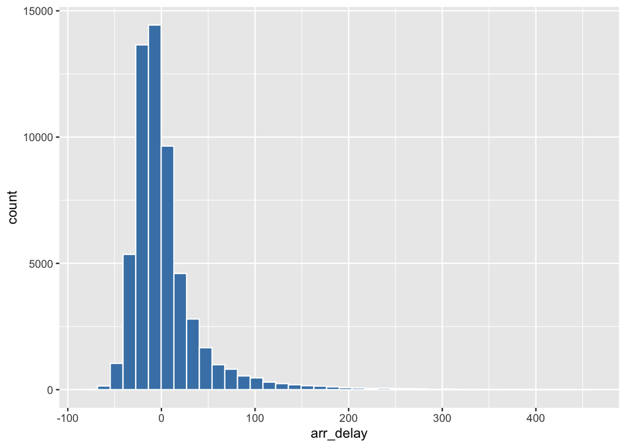

```r
ggplot(data = united_flights, mapping = aes(x = arr_delay)) +
  geom_histogram(bins=40, color="white", fill="steelblue")
```

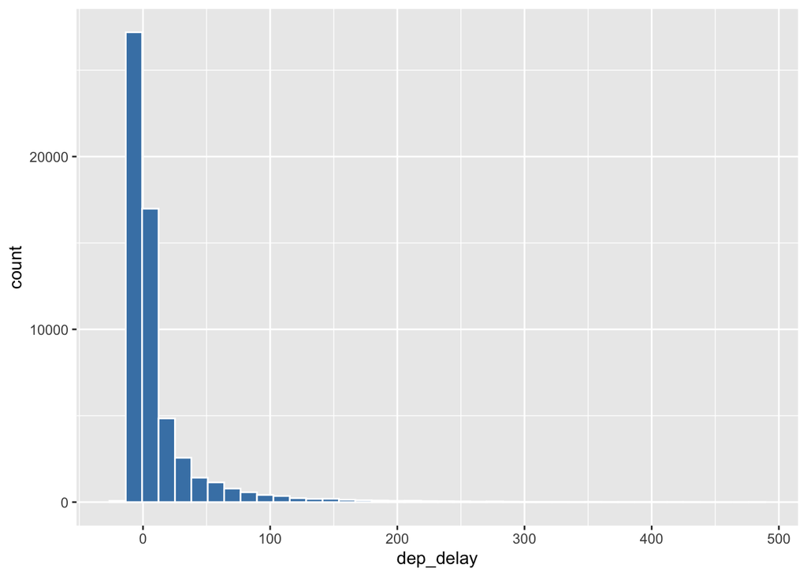

```r
ggplot(data = united_flights, mapping = aes(x = dep_delay)) +
  geom_histogram(bins=40, color="white", fill="steelblue")
```

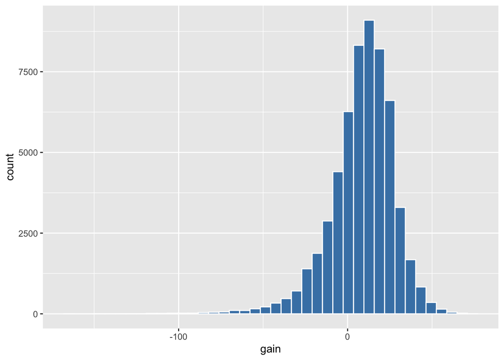

```r
ggplot(data = united_flights, mapping = aes(x = gain)) +
  geom_histogram(bins=40, color="white", fill="steelblue")
```

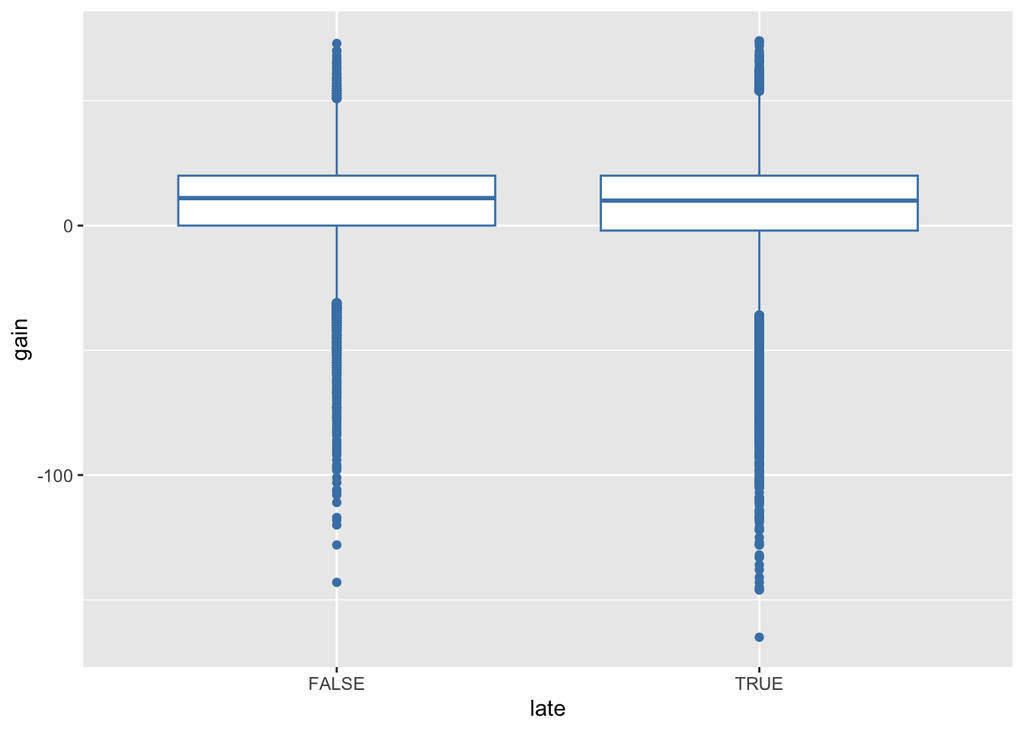

```r
ggplot(data=united_flights, aes(x=late, y=gain))+
geom_boxplot(color="steelblue", fill="white")
```

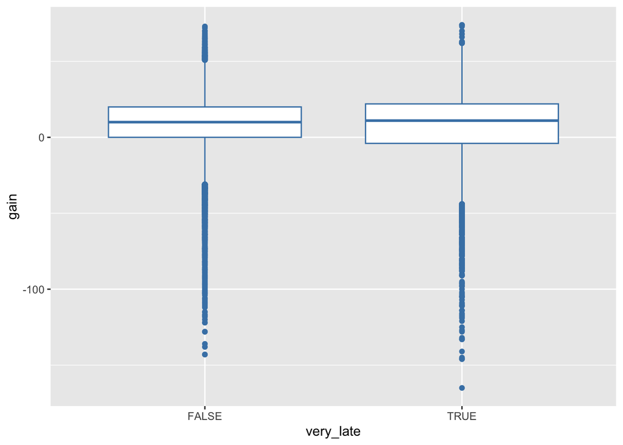

```r
ggplot(data=united_flights, aes(x=very_late, y=gain))+
geom_boxplot(color="steelblue", fill="white")
```

### µ1(Not Late) - µ2(Late) = 0

### µ1(Not Late) - µ2(Late) != 0

```r
t.test(gain~late,united_flights, conf.level= 0.95)
```

```
##
##  Welch Two Sample t-test
##
## data:  gain by late
## t = 10.749, df = 52833, p-value < 2.2e-16
## alternative hypothesis: true difference in means between group FALSE and group TRUE is not equal to 0
## 95 percent confidence interval:
##  1.411308 2.040805
## sample estimates:
## mean in group FALSE  mean in group TRUE
##            9.269172            7.543115
```

### Very Late Hypothesis Test

### µ1(Not Very Late) - µ2(Very Late) = 0

### µ1(Not Very Late) - µ2(Very Late) != 0

```r
t.test(gain~very_late,united_flights, conf.level= 0.95)
```

```
##
##  Welch Two Sample t-test
##
## data:  gain by very_late
## t = 6.2953, df = 8838.6, p-value = 3.215e-10
## alternative hypothesis: true difference in means between group FALSE and group TRUE is not equal to 0
## 95 percent confidence interval:
##  1.268195 2.415112
## sample estimates:
## mean in group FALSE  mean in group TRUE
##            8.699534            6.857881
```

### Both t-tests show significant differences for Late vs. Not Late and Very Late vs. Not Very Late.

### Jacob (five most common destinations)

Below the united_flights data was grouped by the number of flights to each destination airport in descending order.

```r
by_destination <- united_flights %>%
  group_by(dest) %>%
  summarize(count = n()) %>%
  arrange(desc(count))
by_destination
```

| dest | count |
| --- | --- |
| IAH | 6814 |
| ORD | 6744 |
| SFO | 6728 |
| LAX | 5770 |
| DEN | 3737 |
| BOS | 3297 |
| MCO | 3191 |
| FLL | 2376 |
| LAS | 1990 |
| TPA | 1952 |

[output cut: 37 more lines]

Five most common destination airports were determined to be IAH, ORD, SFO, LAX, and DEN. By filtering the data into a set containing only these airports, exploratory data analysis could then be performed to better compare these destinations to one another.

```r
top_five_dest <- united_flights %>%
  filter(dest == "IAH" | dest == "ORD" | dest == "SFO" | dest == "LAX" | dest == "DEN")
```

```r
top_five_dest %>%
  group_by(dest) %>%
  summarize(mean = mean(net_gain)) %>%
  arrange(desc(mean))
```

| dest | mean |
| --- | --- |
| SFO | 8.695006 |
| LAX | 7.825303 |
| ORD | 7.777432 |
| DEN | 7.302382 |
| IAH | 6.861755 |

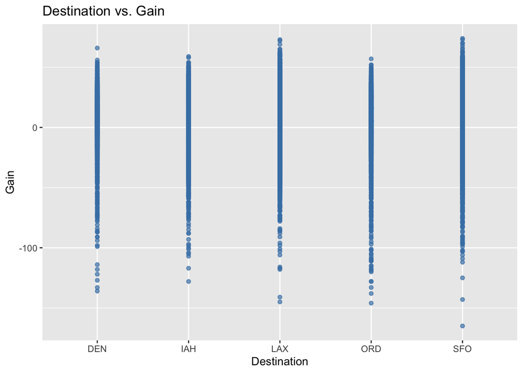

```r
ggplot(data = top_five_dest, aes(x = dest, y = net_gain))+
  geom_point(color = "steelblue", alpha = 0.7) +
  labs(title = "Destination vs. Gain",
       x = "Destination",
       y = "Gain")
```

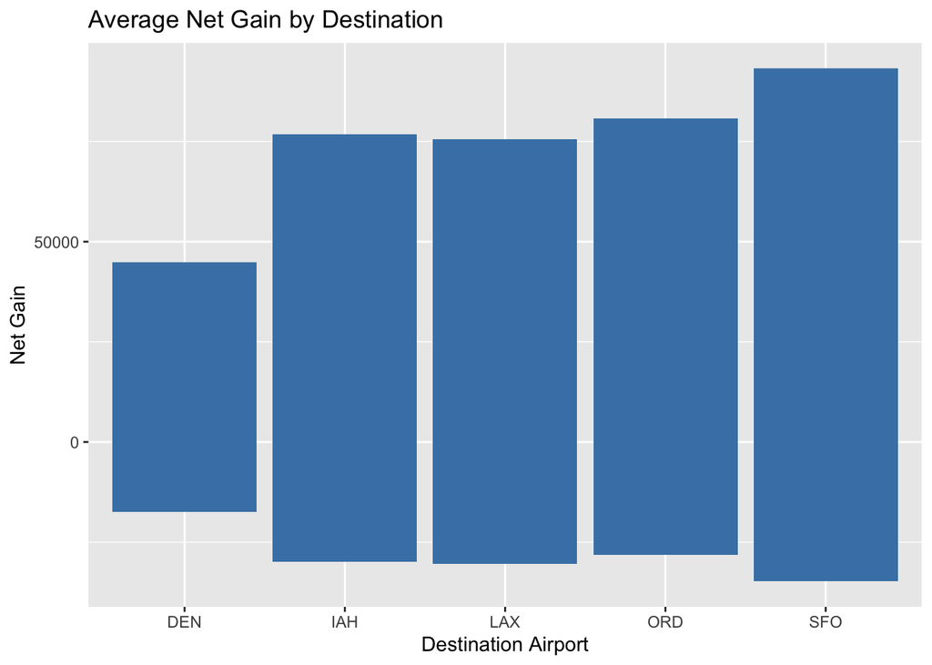

```r
ggplot(data = top_five_dest, aes(x = dest, y = net_gain)) +
  geom_col(fill = "steelblue") +
  labs(title = "Average Net Gain by Destination",
       x = "Destination Airport",
       y = "Net Gain")
```

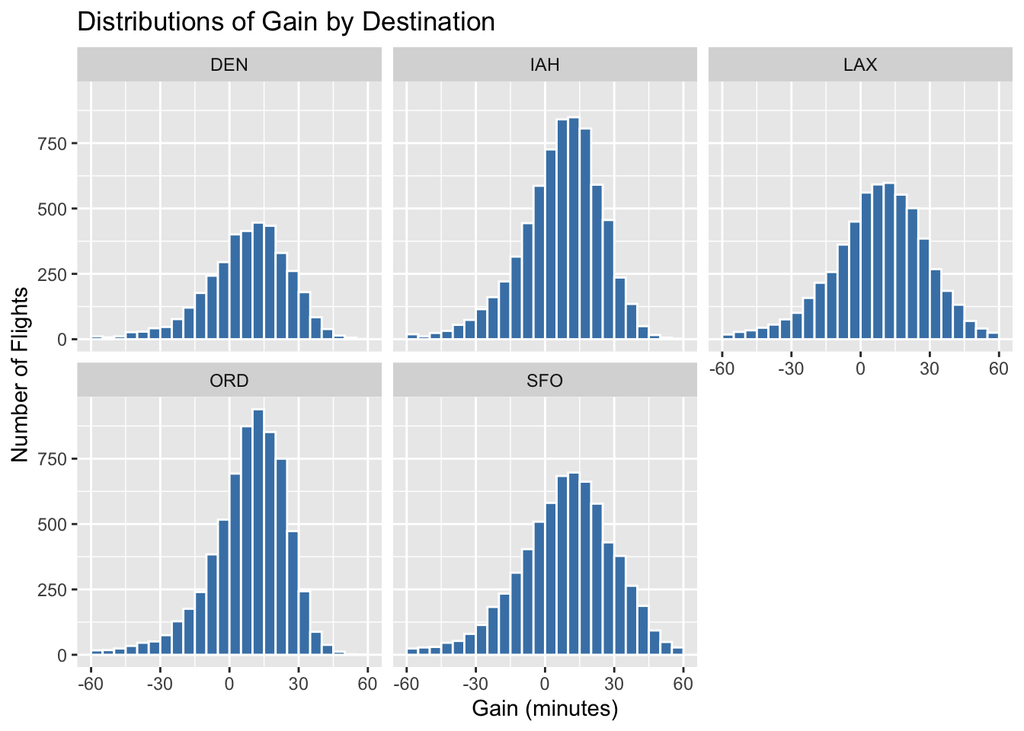

```r
ggplot(data = top_five_dest, mapping = aes(x = net_gain)) +
  geom_histogram(breaks=seq(-60,60, by=5), color="white", fill="steelblue") +
  facet_wrap(~ dest)   +
  labs(title = "Distributions of Gain by Destination",
       x = "Gain (minutes)",
       y = "Number of Flights")
```

When plotting the distribution of each destination individually, they all broadly share this left skew.

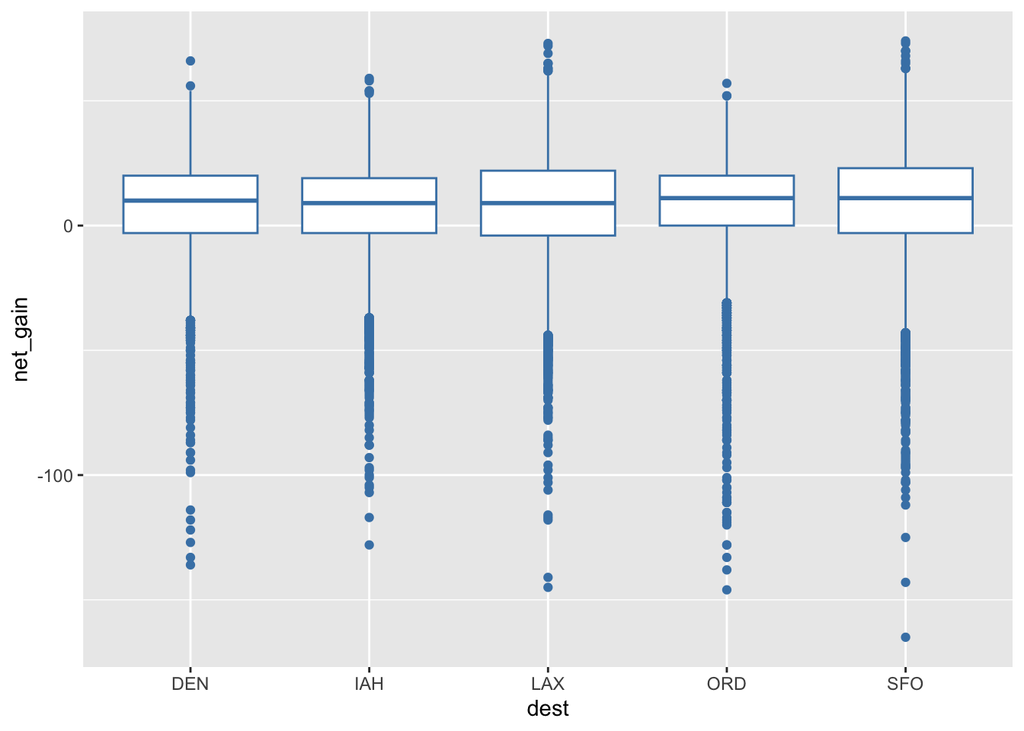

```r
ggplot(data=top_five_dest, aes(x=dest, y=net_gain))+
geom_boxplot(color="steelblue", fill="white")
```

The generated boxplot showed very similar distributions, medians, and number of outliers for each of the five destinations.

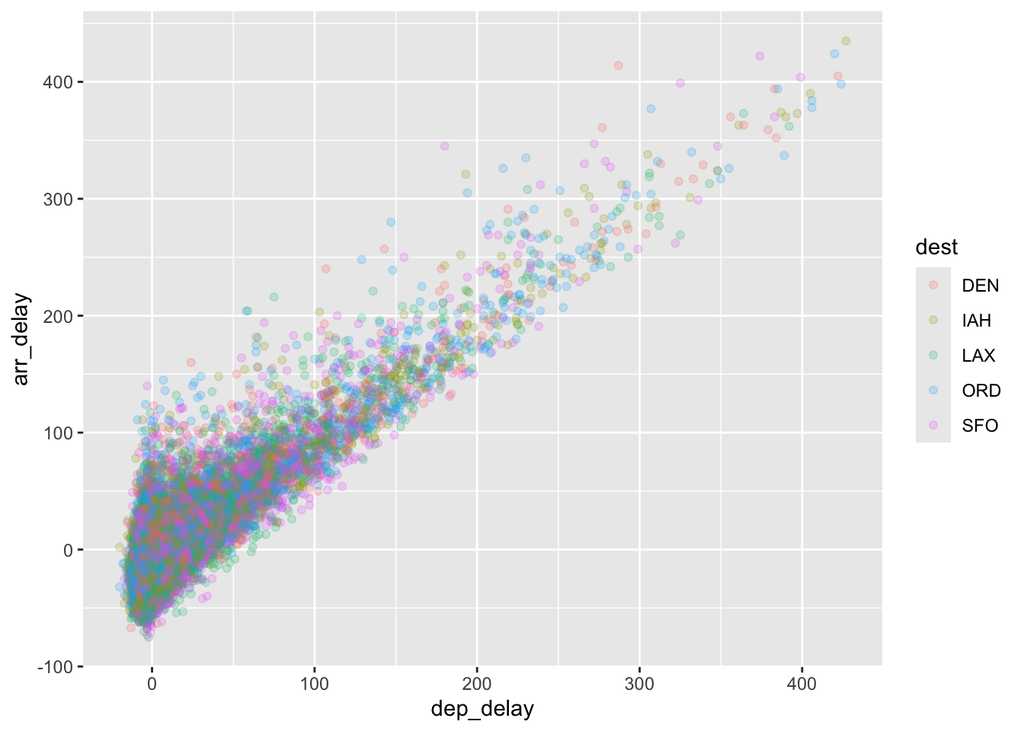

```r
ggplot(data = top_five_dest, aes(x = dep_delay, y = arr_delay, color = dest))+
  geom_point(alpha = 0.2)
```

This code above was designed to see if there were any observable patterns in departure delay and arrival delay between the five airports. The plot did not indicate any clear pattern.

**Hypothesis testing**: Difference in average net gain between airports

### Filtering by each of the airports to compare each of them in our CI t tests.

```r
united_iah_ord <- united_flights %>%
  filter(dest == "IAH" | dest == "ORD")
united_iah_sfo <- united_flights %>%
  filter(dest == "IAH" | dest == "SFO")
united_iah_lax <- united_flights %>%
  filter(dest == "IAH" | dest == "LAX")
united_iah_den <- united_flights %>%
  filter(dest == "IAH" | dest == "DEN")
united_ord_sfo <- united_flights %>%
  filter(dest == "ORD" | dest == "SFO")
united_ord_lax <- united_flights %>%
  filter(dest == "ORD" | dest == "LAX")
united_ord_den <- united_flights %>%
  filter(dest == "ORD" | dest == "DEN")
united_sfo_lax <- united_flights %>%
  filter(dest == "SFO" | dest == "LAX")
united_sfo_den <- united_flights %>%
  filter(dest == "SFO" | dest == "DEN")
united_lax_den <- united_flights %>%
  filter(dest == "LAX" | dest == "DEN")
```

#### IAH vs ORD

```r
t.test(net_gain~dest, data = united_iah_ord, conf.level = .95)
```

```
##
##  Welch Two Sample t-test
##
## data:  net_gain by dest
## t = -2.8349, df = 13524, p-value = 0.00459
## alternative hypothesis: true difference in means between group IAH and group ORD is not equal to 0
## 95 percent confidence interval:
##  -1.5487933 -0.2825599
## sample estimates:
## mean in group IAH mean in group ORD
##          6.861755          7.777432
```

Result: 95% CI: (-1.5487933, -0.2825599); p-value = 0.00459

#### IAH vs SFO

```r
t.test(net_gain~dest, data = united_iah_sfo, conf.level = .95)
```

```
##
##  Welch Two Sample t-test
##
## data:  net_gain by dest
## t = -5.1948, df = 12995, p-value = 2.08e-07
## alternative hypothesis: true difference in means between group IAH and group SFO is not equal to 0
## 95 percent confidence interval:
##  -2.524986 -1.141515
## sample estimates:
## mean in group IAH mean in group SFO
##          6.861755          8.695006
```

Result: 95% CI: (-2.524986, -1.141515); p-value = 2.08e-07

#### IAH vs LAX

```r
t.test(net_gain~dest, data = united_iah_lax, conf.level = .95)
```

```
##
##  Welch Two Sample t-test
##
## data:  net_gain by dest
## t = -2.6405, df = 11316, p-value = 0.008289
## alternative hypothesis: true difference in means between group IAH and group LAX is not equal to 0
## 95 percent confidence interval:
##  -1.6788261 -0.2482701
## sample estimates:
## mean in group IAH mean in group LAX
##          6.861755          7.825303
```

#### IAH vs DEN

```r
t.test(net_gain~dest, data = united_iah_den, conf.level = .95)
```

```
##
##  Welch Two Sample t-test
##
## data:  net_gain by dest
## t = 1.1104, df = 7161.6, p-value = 0.2669
## alternative hypothesis: true difference in means between group DEN and group IAH is not equal to 0
## 95 percent confidence interval:
##  -0.337286  1.218539
## sample estimates:
## mean in group DEN mean in group IAH
##          7.302382          6.861755
```

Result: 95% CI: (-0.337286, 1.218539); p-value = 0.2669

#### ORD vs SFO

```r
t.test(net_gain~dest, data = united_ord_sfo, conf.level = .95)
```

```
##
##  Welch Two Sample t-test
##
## data:  net_gain by dest
## t = -2.5543, df = 13143, p-value = 0.01065
## alternative hypothesis: true difference in means between group ORD and group SFO is not equal to 0
## 95 percent confidence interval:
##  -1.6217238 -0.2134245
## sample estimates:
## mean in group ORD mean in group SFO
##          7.777432          8.695006
```

Result: 95% CI: (-1.6217238, -0.2134245); p-value = 0.01065

#### ORD vs LAX

```r
t.test(net_gain~dest, data = united_ord_lax, conf.level = .95)
```

```
##
##  Welch Two Sample t-test
##
## data:  net_gain by dest
## t = 0.12902, df = 11553, p-value = 0.8973
## alternative hypothesis: true difference in means between group LAX and group ORD is not equal to 0
## 95 percent confidence interval:
##  -0.6794182  0.7751612
## sample estimates:
## mean in group LAX mean in group ORD
##          7.825303          7.777432
```

Result: 95% CI: (-0.6794182, 0.7751612); p-value = 0.8973

#### ORD vs DEN

```r
t.test(net_gain~dest, data = united_ord_den, conf.level = .95)
```

```
##
##  Welch Two Sample t-test
##
## data:  net_gain by dest
## t = -1.1803, df = 7420, p-value = 0.2379
## alternative hypothesis: true difference in means between group DEN and group ORD is not equal to 0
## 95 percent confidence interval:
##  -1.2640195  0.3139191
## sample estimates:
## mean in group DEN mean in group ORD
##          7.302382          7.777432
```

Result: 95% CI: (-1.2640195, 0.3139191); p-value = 0.2379

#### SFO vs LAX

```r
t.test(net_gain~dest, data = united_sfo_lax, conf.level = .95)
```

```
##
##  Welch Two Sample t-test
##
## data:  net_gain by dest
## t = -2.1888, df = 12283, p-value = 0.02863
## alternative hypothesis: true difference in means between group LAX and group SFO is not equal to 0
## 95 percent confidence interval:
##  -1.64854999 -0.09085532
## sample estimates:
## mean in group LAX mean in group SFO
##          7.825303          8.695006
```

Result: 95% CI: (-1.64854999, -0.09085532); p-value = 0.02863

#### SFO vs DEN

```r
t.test(net_gain~dest, data = united_sfo_den, conf.level = .95)
```

```
##
##  Welch Two Sample t-test
##
## data:  net_gain by dest
## t = -3.2626, df = 8457.4, p-value = 0.001108
## alternative hypothesis: true difference in means between group DEN and group SFO is not equal to 0
## 95 percent confidence interval:
##  -2.2293525 -0.5558962
## sample estimates:
## mean in group DEN mean in group SFO
##          7.302382          8.695006
```

Result: 95% CI: (-2.2293525, -0.5558962); p-value = 0.001108

#### LAX vs DEN

```r
t.test(net_gain~dest, data = united_lax_den, conf.level = .95)
```

```
##
##  Welch Two Sample t-test
##
## data:  net_gain by dest
## t = -1.1971, df = 8470.7, p-value = 0.2313
## alternative hypothesis: true difference in means between group DEN and group LAX is not equal to 0
## 95 percent confidence interval:
##  -1.3792086  0.3333652
## sample estimates:
## mean in group DEN mean in group LAX
##          7.302382          7.825303
```

Result: 95% CI: (-1.3792086, 0.3333652); p-value = 0.2313

SFO saw statistically signifcant differences in average net gain relative to all other airports, though the differences for each pair were relatively small (0-2 minutes).

## (Jack L (Question 3))

## Hourly Air-Time Gain/Loss vs. Departure Delays

Another common measure of interest, in addition to total gain, is the gain relative to the duration of the flight. Calculate the gain per hour by dividing the total gain by the duration in hours of each flight. Does the average gain per hour differ for flights that departed late versus those that did not? What about for flights that departed more than 30 minutes late?

### Distribution of Flight Time Gains

The histogram below shows the distribution of flight time gain or loss per hour for United flights.

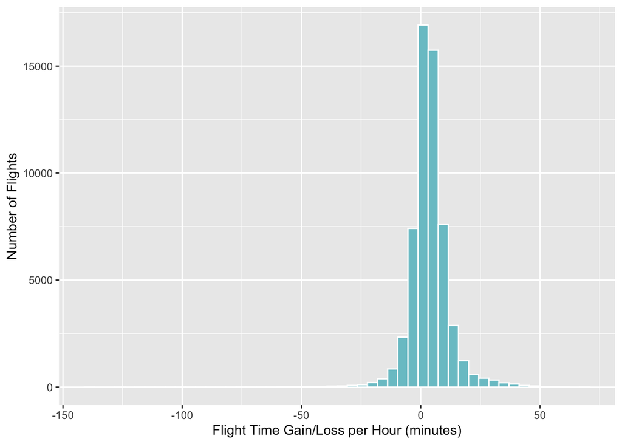

```r
ggplot(data = united_flights, mapping = aes(x = gain_per_hour)) +
      geom_histogram(color = "white",bins = 50,fill = "cadetblue3") +
      labs(y = "Number of Flights",
       x = "Flight Time Gain/Loss per Hour (minutes)")
```

The distribution is highly concentrated around 0 minutes per hour, indicating that most flights neither gain nor lose much time relative to their scheduled duration. Approximately three-quarters of flights cluster very close to zero.

### Distribution of Departure Delays

Before examining the relationship between departure delays and in-flight time recovery, we first explore the distribution of departure delays themselves.

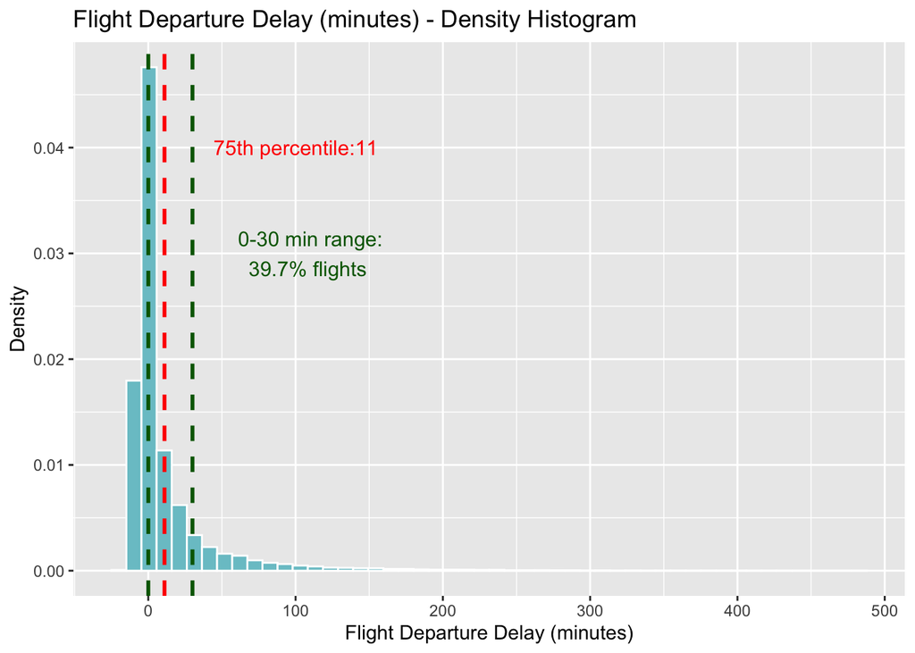

```r
# Calculate percentages and quantiles
percentage_0_30 <- mean(united_flights$dep_delay >= 0 &
                        united_flights$dep_delay <= 30,
                        na.rm = TRUE) * 100
quant75 <- quantile(united_flights$dep_delay, 0.75, na.rm = TRUE)

ggplot(united_flights, aes(x = dep_delay)) +
  geom_histogram(aes(y = after_stat(density)), bins = 50, color = "white", fill = "cadetblue3") +
  geom_vline(xintercept = c(0, 30), color = "darkgreen", linetype = "dashed", linewidth = 1) +
  geom_vline(xintercept = quant75, color = "red", linetype = "dashed", linewidth = 1) +
  annotate("text", x = 15, y = 0.03, hjust = -0.45,
           label = paste0("0-30 min range: \n   ", round(percentage_0_30, 1), "% flights"),
           color = "darkgreen", size = 4) +
  annotate("text", x = quant75, y = 0.04, hjust = -0.3,
           label = paste0("75th percentile:", round(quant75, 2)),
           color = "red", size = 4) +
  labs(x = "Flight Departure Delay (minutes)",
       y = "Density",
       title = "Flight Departure Delay (minutes) - Density Histogram")
```

The distribution of departure delays is heavily right-skewed, with the majority of flights concentrated near zero minutes. This indicates that most United flights depart close to their scheduled time. Approximately 39.7% of flights fall within the 0-30 minute delay range, representing short delays that are relatively common. The 75th percentile is around 11 minutes, meaning three-quarters of all flights depart with a delay of 11 minutes or less. The long tail extending to the right shows that while severe delays do occur, they are relatively rare compared to on-time or minimally delayed departures.

### Departure Delays and Flight Time Gain per Hour

To understand whether departure delays affect in-flight time recovery, we examine the relationship between departure delay and flight time gain per hour across three increasingly detailed views.

#### Overall Relationship

The scatter plot below examines the relationship between departure delay and flight time gain per hour for all United flights, with a linear regression line showing the overall trend.

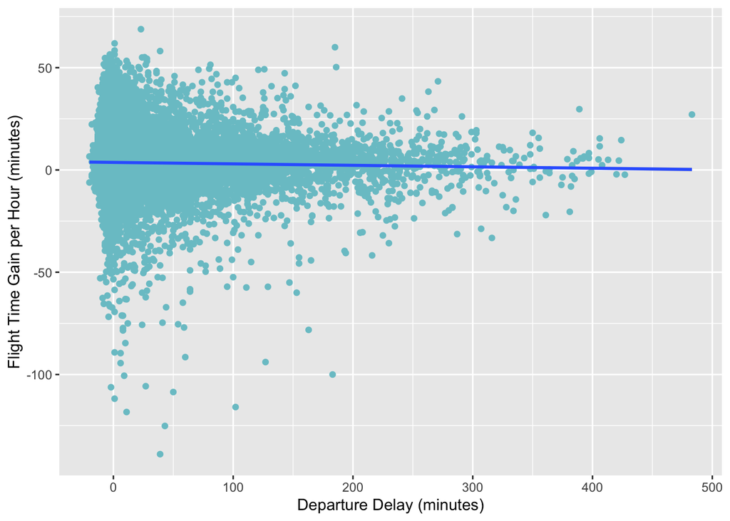

```r
ggplot(united_flights, aes(x=dep_delay, y = gain_per_hour)) +
  geom_point(color = "cadetblue3") +
  geom_smooth(method = "lm", se = TRUE, fullrange = TRUE) +
  labs(x = "Departure Delay (minutes)",
       y = "Flight Time Gain per Hour (minutes)")
```

```r
  geom_smooth(method = "lm", se = TRUE, fullrange = TRUE,
              color = "lightblue",
              fill = "lightblue")
```

```
## geom_smooth: na.rm = FALSE, orientation = NA, se = TRUE
## stat_smooth: na.rm = FALSE, orientation = NA, se = TRUE, fullrange = TRUE, method = lm
## position_identity
```

The plot shows no strong relationship between departure delays and the amount of air-time gained per hour. Flights generally maintain consistent air-time performance regardless of how delayed the departure was.

#### Comparing Late vs. On-Time Flights

We now separate flights into two categories to see if departure status reveals different patterns.

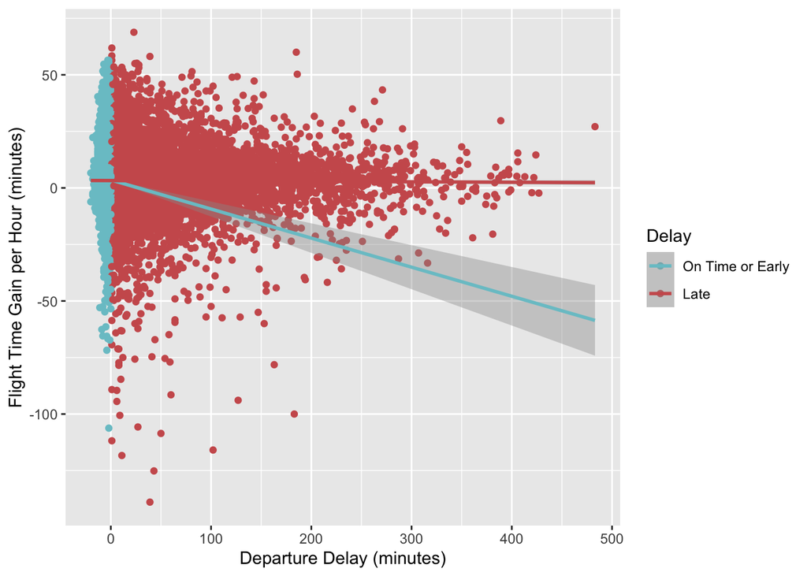

```r
ggplot(united_flights, aes(x=dep_delay, y = gain_per_hour, color = late)) +
  geom_point() +
  geom_smooth(method = "lm", se = TRUE, fullrange = TRUE) +
  labs(x = "Departure Delay (minutes)",
       y = "Flight Time Gain per Hour (minutes)",
       color = "Delay") +
  scale_color_manual(values = c("FALSE" = "cadetblue3", "TRUE" = "indianred"),
                     labels = c("On Time or Early", "Late"))
```

The on-time or early group displays a clear negative slope, while late flights maintain a relatively flat trend around zero gain. This downward slope for on-time/early flights is primarily driven by flights that departed ahead of schedule. These early departures leave with a time buffer but tend to give back that advantage during flight, resulting in negative gain per hour.

#### Impact of Very Late Departures (>30 minutes)

We also isolate flights with severe delays (>30 minutes) to examine whether extreme delays show different behavior.

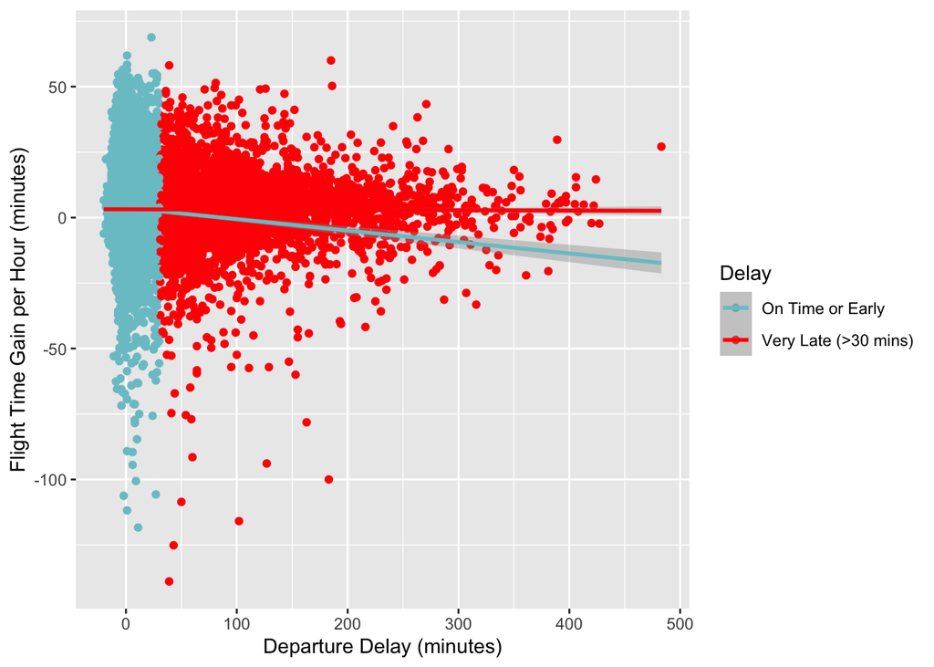

```r
ggplot(united_flights, aes(x=dep_delay, y = gain_per_hour, color = very_late)) +
  geom_point() +
  geom_smooth(method = "lm", se = TRUE, fullrange = TRUE) +
  labs(x = "Departure Delay (minutes)",
       y = "Flight Time Gain per Hour (minutes)",
       color = "Delay") +
  scale_color_manual(values = c("FALSE" =  "cadetblue3", "TRUE" ="red"),
                     labels = c("On Time or Early", "Very Late (>30 mins)"))
```

In this comparison, the blue group now includes all flights except those with very late departures (>30 minutes), combining early departures with flights delayed 0-30 minutes. The negative slope observed is less steep than in the previous plot because the effect of early departures is now averaged with slightly delayed flights (0-30 minutes).

## Focusing on Typical Delays: Flights Delayed 30 Minutes or Less

```r
united_flights_delay_below_30min <-united_flights %>%
  filter(dep_delay <= 30)
```

### Overall Pattern for Flights Delayed ≤30 Minutes

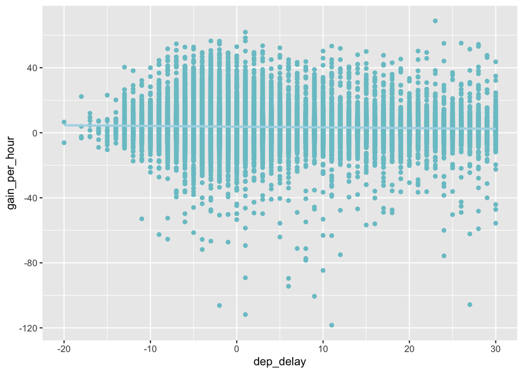

```r
ggplot(united_flights_delay_below_30min, aes(x=dep_delay, y = gain_per_hour)) +
  geom_point(color = "cadetblue3") +
  geom_smooth(method = "lm", se = TRUE, fullrange = TRUE,
              color = "lightblue",
              fill = "lightblue")
```

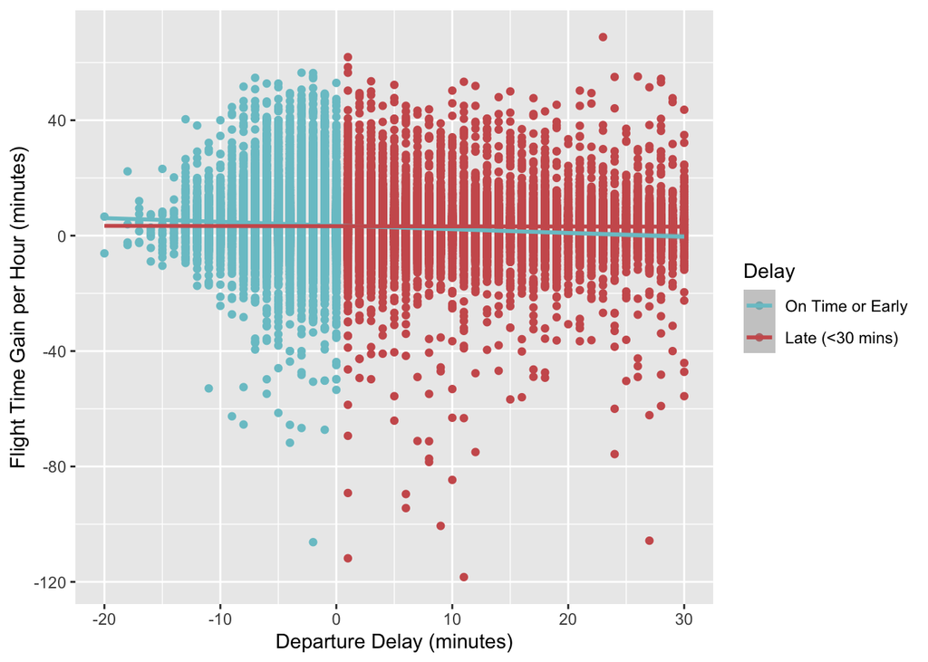

```r
ggplot(united_flights_delay_below_30min, aes(x=dep_delay, y = gain_per_hour, color = late)) +
  geom_point() +
  geom_smooth(method = "lm", se = TRUE, fullrange = TRUE) +
  labs(x = "Departure Delay (minutes)",
       y = "Flight Time Gain per Hour (minutes)",
       color = "Delay") +
  scale_color_manual(values = c("FALSE" =  "cadetblue3", "TRUE" ="indianred"),
                     labels = c("On Time or Early", "Late (<30 mins)"))
```

.Within this typical delay range, United Airlines pilots maintain consistent in-flight performance regardless of whether flights departed early, on-time, or slightly late. This suggests that even moderate delays do not substantially impact a flight’s ability to maintain schedule during the air portion of the journey.

## Hypothesis Testing: Impact of Departure Delays on In-Flight Performance

To quantify the observations from our visualizations, we test two specific hypotheses about flight time recovery.

### Hypothesis 1: Do flights with moderate delays (≤30 minutes) differ from the overall average?

We test whether flights delayed 30 minutes or less recover a different amount of time compared to all United flights.

```r
overall_mean <- mean(united_flights$gain_per_hour)

t.test(united_flights_delay_below_30min$gain_per_hour, mu = overall_mean, conf.level = 0.95)
```

```
##
##  One Sample t-test
##
## data:  united_flights_delay_below_30min$gain_per_hour
## t = 2.2886, df = 50231, p-value = 0.02211
## alternative hypothesis: true mean is not equal to 3.612383
## 95 percent confidence interval:
##  3.624206 3.765248
## sample estimates:
## mean of x
##  3.694727
```

**Result:**

Flights that departed with delays of 30 minutes or less recovered an average of 3.69 minutes per flight hour, compared to United Airlines’ overall average of 3.61 minutes per hour. A one-sample t-test shows that flights with moderate or no departure delays recover slightly but significantly more time than the airline’s overall average (p = 0.022). We are 95% confident that the true average recovery for these flights lies between 3.62 and 3.77 minutes per hour. While statistically significant, the practical difference is quite small—only about 5 seconds per hour.

### Hypothesis 2: Do very late flights (>30 minutes) recover less time than flights delayed ≤30 minutes?

We test whether flights with severe delays (>30 minutes) show meaningfully worse in-flight time recovery compared to flights with moderate delays.

```r
t.test(gain_per_hour ~ very_late, data = united_flights,
       alternative = "greater", var.equal = TRUE, conf.level = 0.95)
```

```
##
##  Two Sample t-test
##
## data:  gain_per_hour by very_late
## t = 6.0157, df = 57780, p-value = 9.01e-10
## alternative hypothesis: true difference in means between group FALSE and group TRUE is greater than 0
## 95 percent confidence interval:
##  0.4578833       Inf
## sample estimates:
## mean in group FALSE  mean in group TRUE
##            3.694727            3.064527
```

Flights delayed more than 30 minutes recover, on average, about 38 seconds less per hour flown than flights delayed 30 minutes or less. A one-sided t-test confirms this disadvantage is highly significant (p ≈ 9.01e-10), and we are 95% confident the true difference is at least 0.46 minutes per hour.

However, while statistically significant, the practical impact is modest—less than one minute per hour on average. This suggests that a severe ground delay (>30 minutes) does not translate into dramatically worse in-flight performance.

[output not shown]

# EDA

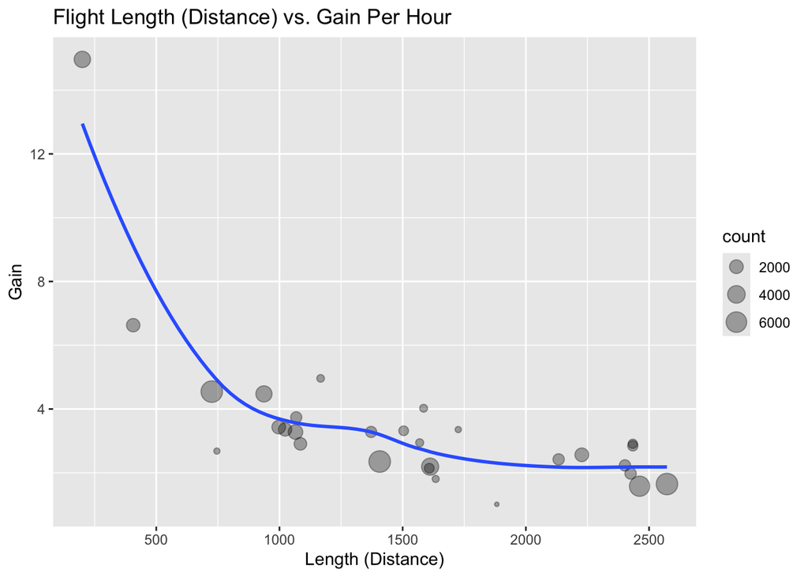

```r
by_dest <- group_by(united_flights, dest)
gain <- summarise(by_dest,
  count = n(),
  distance = mean(distance, na.rm = TRUE),
  gain_per_hour = mean(gain_per_hour, na.rm = TRUE)
)

#filter out Honolulu because it is a huge outlier (distance is 5000, next closest is closer to 3000 miles)
gain <- filter(gain, count > 20, dest != "HNL")

ggplot(data = gain, mapping = aes(x = distance, y = gain_per_hour)) +
  geom_point(aes(size = count), alpha = 1/3) +
  geom_smooth(se = FALSE)+
  labs(title = "Flight Length (Distance) vs. Gain Per Hour",
       x = "Length (Distance)",
       y = "Gain")
```

```r
long_distance_flights <- filter(united_flights, distance >= 3000)
nrow(long_distance_flights)
```

```
## [1] 367
```

```r
long_distance_flights <- filter(united_flights, distance >= 3000, dest!= 'HNL')
nrow(long_distance_flights)
```

```
## [1] 8
```

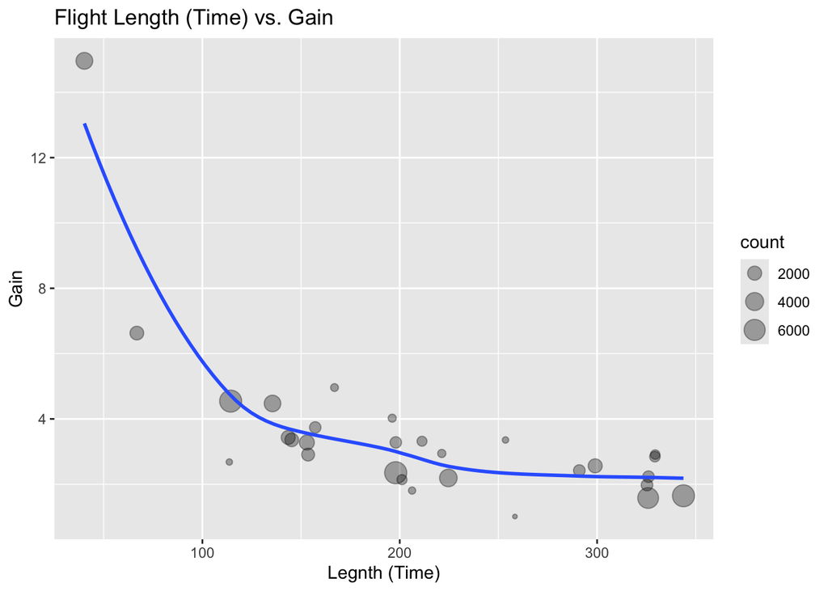

```r
by_dest <- group_by(united_flights, dest)
gain_air <- summarise(by_dest,
  count = n(),
  air_time = mean(air_time, na.rm = TRUE),
  gain_per_hour = mean(gain_per_hour, na.rm = TRUE)
)
# filter out Honolulu because it is an outlier and twice as far away (airtime was 600)
gain_air <- filter(gain_air, count > 20, dest != "HNL")

ggplot(data = gain_air, mapping = aes(x = air_time, y = gain_per_hour)) +
  geom_point(aes(size = count), alpha = 1/3) +
  geom_smooth(se = FALSE)+
  labs(title = "Flight Length (Time) vs. Gain",
       x = "Legnth (Time)",
       y = "Gain")
```

## Look at Averages and Medians to get an idea of spread for both variables

```r
# Average gain for short flights (time)
united_flights %>%
  filter(air_time < 180) %>%
  summarise(avg_time_gain = mean(gain_per_hour, na.rm = TRUE),
            median_time_gain = median(gain_per_hour, na.rm = TRUE))
```

| avg_time_gain | median_time_gain |
| --- | --- |
| 5.874679 | 5.696203 |

```r
# Average gain for short flights (distance)
united_flights %>%
  filter(distance < 700, dest!='HNL') %>%
  summarise(avg_dist_gain = mean(gain_per_hour, na.rm = TRUE),
            median_dist_gain = median(gain_per_hour, na.rm = TRUE))
```

| avg_dist_gain | median_dist_gain |
| --- | --- |
| 11.92329 | 12.85714 |

Mean and median are roughly equal for both variables (time and distance).

## Set time and distance flight variable

```r
time_flights <-united_flights %>%
  filter(!is.na(gain_per_hour)) %>%
  filter(dest!= 'HNL')%>%
  mutate(short_time = air_time <= 180)%>%
  mutate(long_time = air_time>180)

dist_flights <-united_flights %>%
  filter(!is.na(gain_per_hour)) %>%
  filter(dest!= 'HNL')%>%
  mutate(short_dist = distance <=700)%>%
  mutate(long_dist = distance >700)
```